# 市场观察

2017/02/28

## A、指数估值

### (a)动态市盈率、市净率

核心指数成分股近18个月的动态市盈率及动态市净率中位数走势如下图所示：

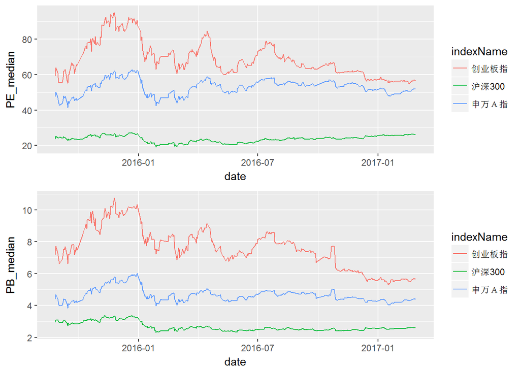

### (b)动态市盈率、市净率百分位

核心指数近18个月的动态市盈率百分位及动态市净率百分位走势如下图所示：

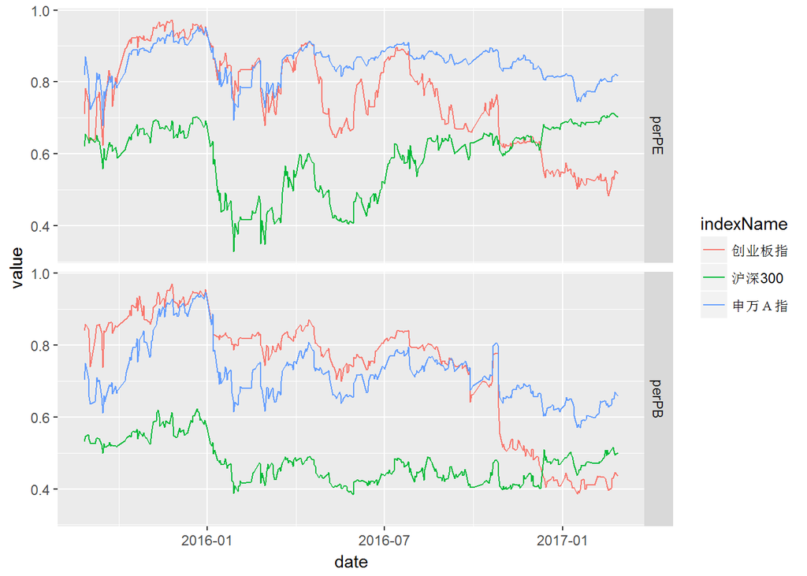

### (c)指数估值概览

| 日期 | 指数代码 | 指数简称 | 动态市盈率 | 市盈率百分位 | 动态市净率 | 市净率百分位 |
| --- | --- | --- | --- | --- | --- | --- |
| 2017-02-27 | EI000979 | 大宗商品 | 55.8 | 97.5% | 3.1 | 76.4% |
| 2017-02-27 | EI000819 | 有色金属 | 63.2 | 87.5% | 3.9 | 79.5% |
| 2017-02-27 | EI801003 | 申万Ａ指 | 51.8 | 81.8% | 4.4 | 65.8% |
| 2017-02-27 | EI399005 | 中小板指P | 44.2 | 76.1% | 4.8 | 49.7% |
| 2017-02-27 | EI000827 | 中证环保 | 43.7 | 76.0% | 3.2 | 33.4% |
| 2017-02-27 | EI000933 | 中证医药 | 40.8 | 71.0% | 4.0 | 9.7% |
| 2017-02-27 | EI000300 | 沪深300 | 26.1 | 70.2% | 2.6 | 50.1% |
| 2017-02-27 | EI399330 | 深证100 | 33.2 | 69.4% | 4.0 | 62.8% |
| 2017-02-27 | EI000905 | 中证500 | 41.0 | 68.4% | 3.2 | 42.1% |
| 2017-02-27 | EI399959 | 军工指数 | 85.1 | 63.3% | 5.7 | 70.4% |
| 2017-02-27 | EI000934 | 中证金融 | 18.8 | 61.1% | 2.0 | 30.2% |
| 2017-02-27 | EI000016 | 上证50 | 17.6 | 59.3% | 1.7 | 19.2% |
| 2017-02-27 | EI399006 | 创业板指 | 56.8 | 54.5% | 5.7 | 43.7% |
| 2017-02-27 | EI000998 | 中证TMT | 44.1 | 47.8% | 4.3 | 39.2% |
| 2017-02-27 | EI000932 | 中证消费 | 30.7 | 38.9% | 3.8 | 24.4% |

## B、基差

### (a)基差走势

三大股指期货合约基差走势如下图，其中当月合约和次月合约年化基差百分比波动较大，仅展示合约基差百分比，当季合约和次季合约展示基差年化百分比：

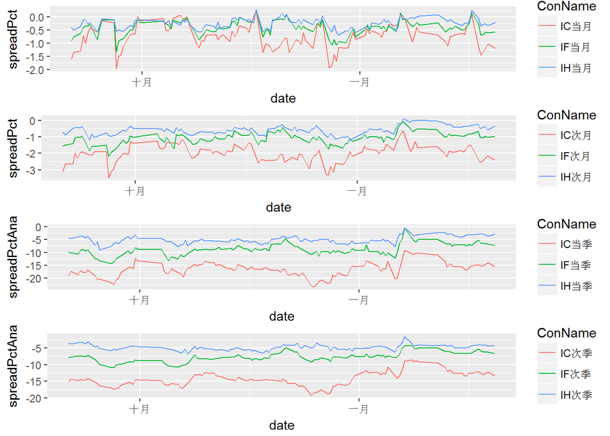

### (b)基差概况

三大股指期货连续合约基差概况如下表，近月合约临近到期日，年化基差百分比数据波动较大：

| 日期 | 合约代码 | 合约收盘价 | 指数收盘价 | 基差 | 基差百分比 | 年化基差百分比 |
| --- | --- | --- | --- | --- | --- | --- |
| 2017-02-27 | IC1703 | 6348.0 | 6424.25 | -76.25 | -1.19% | -27.0% |
| 2017-02-27 | IC1704 | 6270.4 | 6424.25 | -153.85 | -2.39% | -17.7% |
| 2017-02-27 | IC1706 | 6142.0 | 6424.25 | -282.25 | -4.39% | -15.5% |
| 2017-02-27 | IC1709 | 5969.2 | 6424.25 | -455.05 | -7.08% | -13.3% |
| 2017-02-27 | IF1703 | 3426.6 | 3446.22 | -19.62 | -0.57% | -12.2% |
| 2017-02-27 | IF1704 | 3412.4 | 3446.22 | -33.82 | -0.98% | -7.0% |
| 2017-02-27 | IF1706 | 3374.2 | 3446.22 | -72.02 | -2.09% | -7.2% |
| 2017-02-27 | IF1709 | 3323.2 | 3446.22 | -123.02 | -3.57% | -6.6% |
| 2017-02-27 | IH1703 | 2365.8 | 2370.56 | -4.76 | -0.20% | -4.2% |
| 2017-02-27 | IH1704 | 2362.4 | 2370.56 | -8.16 | -0.34% | -2.4% |
| 2017-02-27 | IH1706 | 2350.2 | 2370.56 | -20.36 | -0.86% | -2.9% |
| 2017-02-27 | IH1709 | 2317.6 | 2370.56 | -52.96 | -2.23% | -4.1% |

## C、套利和事件

### (a)复牌股票套利

近两天复牌股票套利情况如下表：

[1] “无复牌股票套利”

### (b)定增基金(provided by han.qian)

截止2017-02-28定增基金数据如下表，明细数据参见钱瀚的模板。

| 代码 | 名称 | 到期日期 | 最新净值 | 昨日收盘价 | 折溢价率 | 整体隐含折价率 | 大盘下跌0.1净值变化 |
| --- | --- | --- | --- | --- | --- | --- | --- |
| 168101.OF | 九泰锐智 | 20200814 | 1.21 | 1.10 | -8.8% | 5.9% | -8.6% |
| 168102.OF | 九泰锐富 | 20210204 | 1.04 | 0.93 | -10.8% | 4.7% | -4.6% |
| 501015.OF | 财通升级 | 20170908 | 1.06 | 1.01 | -4.7% | 4.4% | -8.0% |
| 160518.OF | 博时睿远 | 20171016 | 1.00 | 0.95 | -4.9% | 2.8% | -5.6% |

定增基金近期的净值走势如下图：

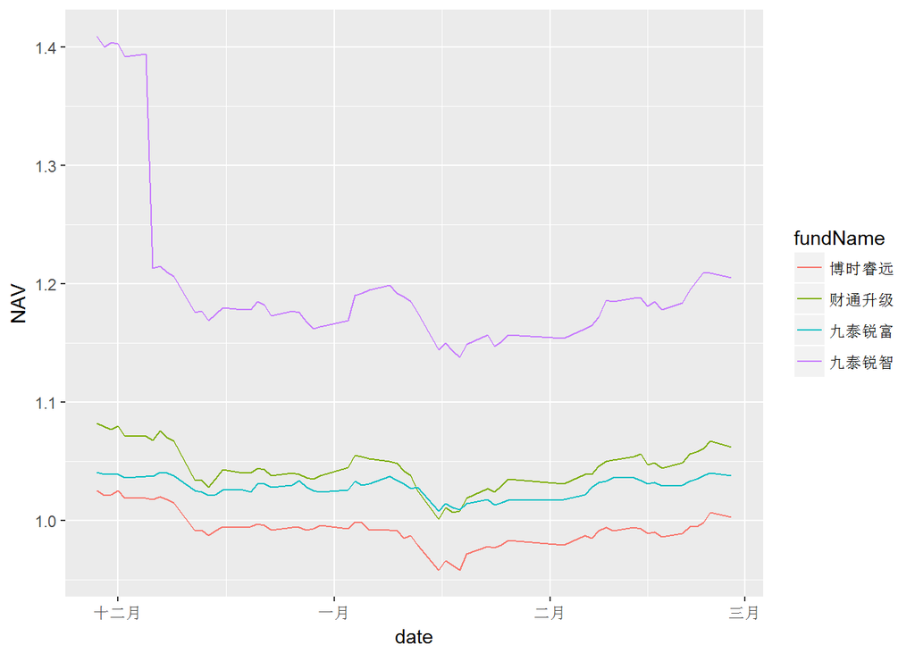

定增基金近期的折溢价率百分比走势如下图：

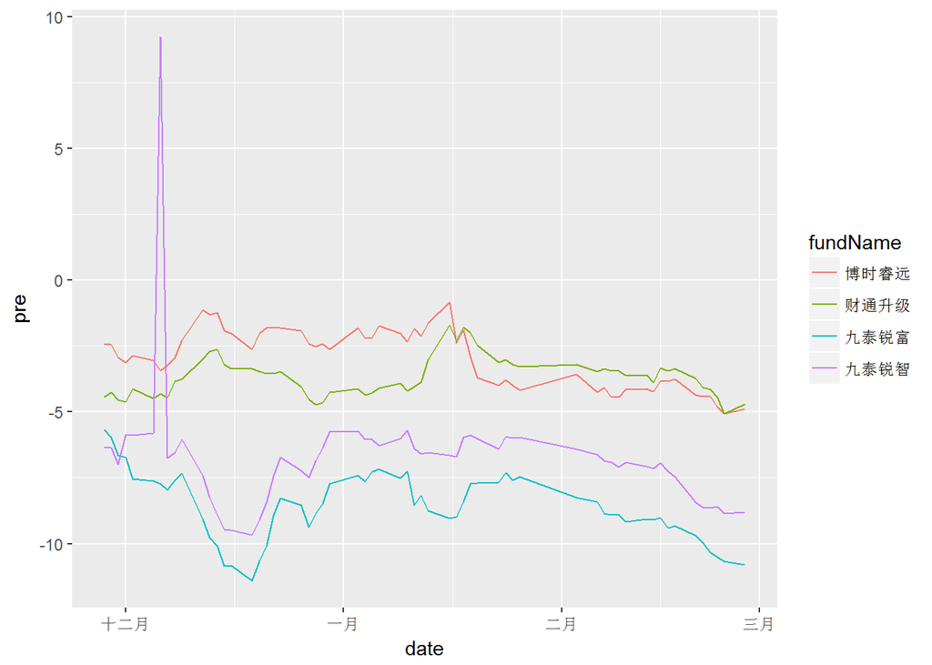

### (c)定增解禁(provided by han.qian)

近十天定增解禁的股票情况如下表。

| 股票代码 | 股票简称 | 跟踪起始日 | 解禁日 | 区间涨跌幅 | 所属行业指数 | 行业指数涨跌幅 |
| --- | --- | --- | --- | --- | --- | --- |
| EQ002517 | 恺英网络 | 2017-02-14 | 2017-02-28 | 9.71% | 申万传媒 | 1.24% |
| EQ002590 | 万安科技 | 2017-02-15 | 2017-03-01 | -4.13% | 申万汽车 | 0.42% |
| EQ601599 | 鹿港文化 | 2017-02-17 | 2017-03-03 | 5.52% | 申万纺织服装 | 0.36% |
| EQ002248 | 华东数控 | 2017-02-20 | 2017-03-06 | 3.24% | 申万机械设备 | 1.86% |
| EQ002360 | 同德化工 | 2017-02-20 | 2017-03-06 | 0.50% | 申万化工 | 0.86% |
| EQ600330 | 天通股份 | 2017-02-20 | 2017-03-06 | 1.20% | 申万有色金属 | 1.46% |
| EQ600487 | 亨通光电 | 2017-02-20 | 2017-03-06 | 2.68% | 申万通信 | 3.16% |
| EQ600616 | 金枫酒业 | 2017-02-21 | 2017-03-07 | 1.77% | 申万食品饮料 | -1.01% |
| EQ600845 | 宝信软件 | 2017-02-21 | 2017-03-07 | -2.49% | 申万计算机 | 2.27% |
| EQ002657 | 中科金财 | 2017-02-22 | 2017-03-08 | 0.28% | 申万计算机 | 0.75% |
| EQ000791 | 甘肃电投 | 2017-02-24 | 2017-03-10 | -1.46% | 申万公用事业 | -0.02% |
| EQ000591 | 太 阳 能 | 2017-02-27 | 2017-03-13 | -2.09% | 申万电气设备 | -0.69% |
| EQ600398 | 海澜之家 | 2017-02-27 | 2017-03-13 | -2.05% | 申万纺织服装 | -0.63% |
| EQ600558 | 大 西 洋 | 2017-02-27 | 2017-03-13 | -2.46% | 申万机械设备 | -0.68% |
| EQ600998 | 九 州 通 | 2017-02-28 | 2017-03-14 | 0.00% | 申万医药生物 | 0.00% |

## D、择时

### (a)等权指数

从历史来看，A股市场存在小盘股效应，市值小的股票长期整体跑赢大市值的股票，美股市场同样存在类似的现象。而目前大部分指数的编制方案都是类似市值加权，为了抛去市值的影响，下面展示几个等权指数，其中中证500等权和沪深300等权是现有的指数，中证全指等权是自己编制的指数。等权指数可以视为一个更好地业绩比较基准。等权指数走势如下图：

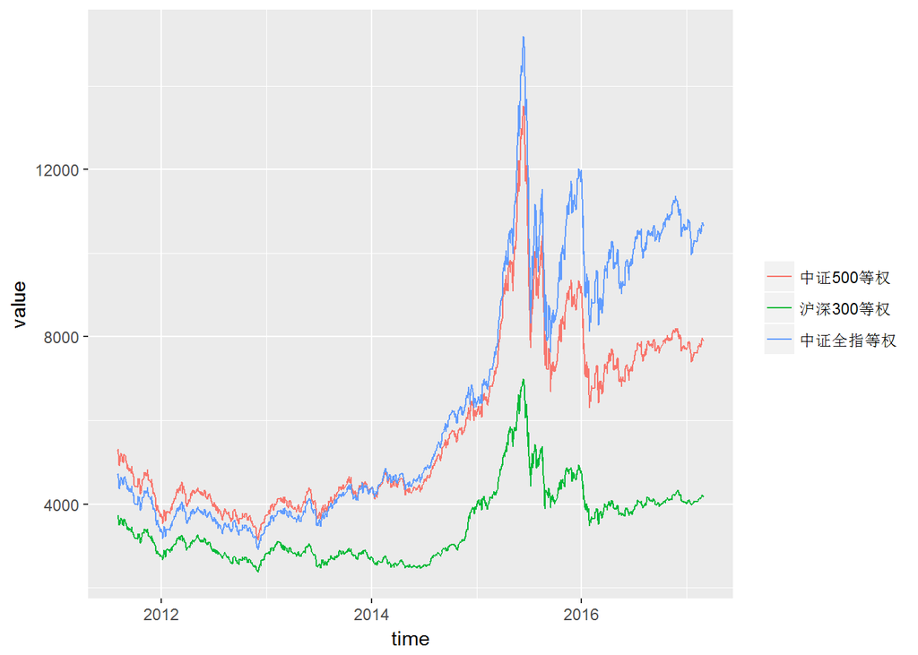

等权指数收益率统计见下表：

|  | 中证500等权 | 沪深300等权 | 中证全指等权 |
| --- | --- | --- | --- |
| 2011-08-02 ~ 2011-12-30 | -29.2% | -25.5% | -27.8% |
| 2012-01-04 ~ 2012-12-31 | -0.0% | 1.5% | 2.3% |
| 2013-01-04 ~ 2013-12-31 | 16.7% | -3.2% | 25.8% |
| 2014-01-02 ~ 2014-12-31 | 40.2% | 43.7% | 46.0% |
| 2015-01-05 ~ 2015-12-31 | 47.6% | 20.1% | 84.4% |
| 2016-01-04 ~ 2016-12-30 | -15.1% | -15.1% | -10.4% |
| 2017-01-03 ~ 2017-02-27 | 2.5% | 3.7% | 0.7% |
| 累计收益率 | 48.8% | 11.3% | 125.8% |
| 年化收益率 | 7.4% | 1.9% | 15.7% |
| 年化波动率 | 28.9% | 26.2% | 29.3% |
| 年化Sharpe值 | 25.5% | 7.4% | 53.6% |
| 最大回撤 | 53.3% | 50.0% | 49.7% |

### (b)大盘均线强弱指数

大盘均线强弱指数在一定程度上可以视为一个反转指标，当大盘均线得分接近8分时，预示市场接近顶部，当大盘均线得分接近0分时，预示市场接近底部。  
大盘均线强弱指数近一年来走势如下图：

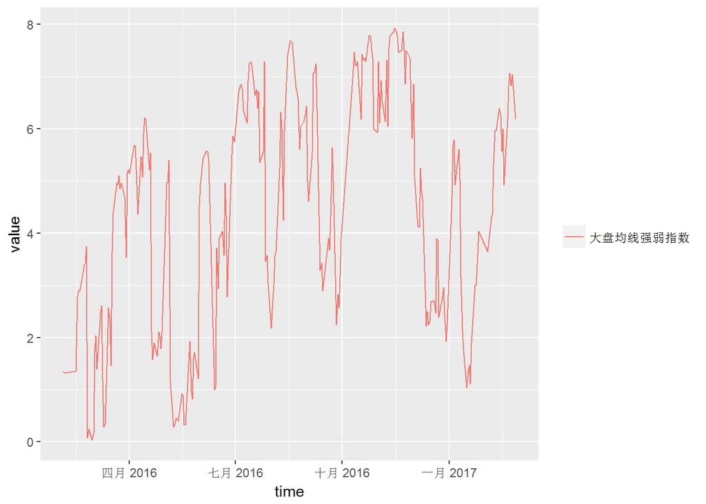

申万一级行业的最新得分见下表：

| 日期 | 指数代码 | 行业 | 最新得分 | 上周得分 |
| --- | --- | --- | --- | --- |
| 2017-02-27 | EI801040 | 钢铁 | 8 | 8 |
| 2017-02-27 | EI801140 | 轻工制造 | 8 | 7 |
| 2017-02-27 | EI801160 | 公用事业 | 8 | 8 |
| 2017-02-27 | EI801210 | 休闲服务 | 8 | 5 |
| 2017-02-27 | EI801880 | 汽车 | 8 | 8 |
| 2017-02-27 | EI801890 | 机械设备 | 8 | 8 |
| 2017-02-27 | EI801050 | 有色金属 | 7 | 8 |
| 2017-02-27 | EI801110 | 家用电器 | 7 | 8 |
| 2017-02-27 | EI801120 | 食品饮料 | 7 | 8 |
| 2017-02-27 | EI801170 | 交通运输 | 7 | 8 |
| 2017-02-27 | EI801200 | 商业贸易 | 7 | 8 |
| 2017-02-27 | EI801780 | 银行 | 7 | 8 |
| 2017-02-27 | EI801030 | 化工 | 6 | 8 |
| 2017-02-27 | EI801080 | 电子 | 6 | 6 |
| 2017-02-27 | EI801130 | 纺织服装 | 6 | 5 |
| 2017-02-27 | EI801150 | 医药生物 | 6 | 5 |
| 2017-02-27 | EI801710 | 建筑材料 | 6 | 8 |
| 2017-02-27 | EI801720 | 建筑装饰 | 6 | 8 |
| 2017-02-27 | EI801730 | 电气设备 | 6 | 6 |
| 2017-02-27 | EI801770 | 通信 | 6 | 5 |
| 2017-02-27 | EI801010 | 农林牧渔 | 5 | 5 |
| 2017-02-27 | EI801230 | 综合 | 5 | 5 |
| 2017-02-27 | EI801740 | 国防军工 | 5 | 8 |
| 2017-02-27 | EI801020 | 采掘 | 4 | 8 |
| 2017-02-27 | EI801180 | 房地产 | 4 | 7 |
| 2017-02-27 | EI801750 | 计算机 | 4 | 4 |
| 2017-02-27 | EI801760 | 传媒 | 4 | 3 |
| 2017-02-27 | EI801790 | 非银金融 | 4 | 8 |

### (c)LLT及均线择时

LLT本质上是一个改进的单均线择时指标，较原始的均线择时延迟更低。  
择时模型和指数本身的净值走势如下图：

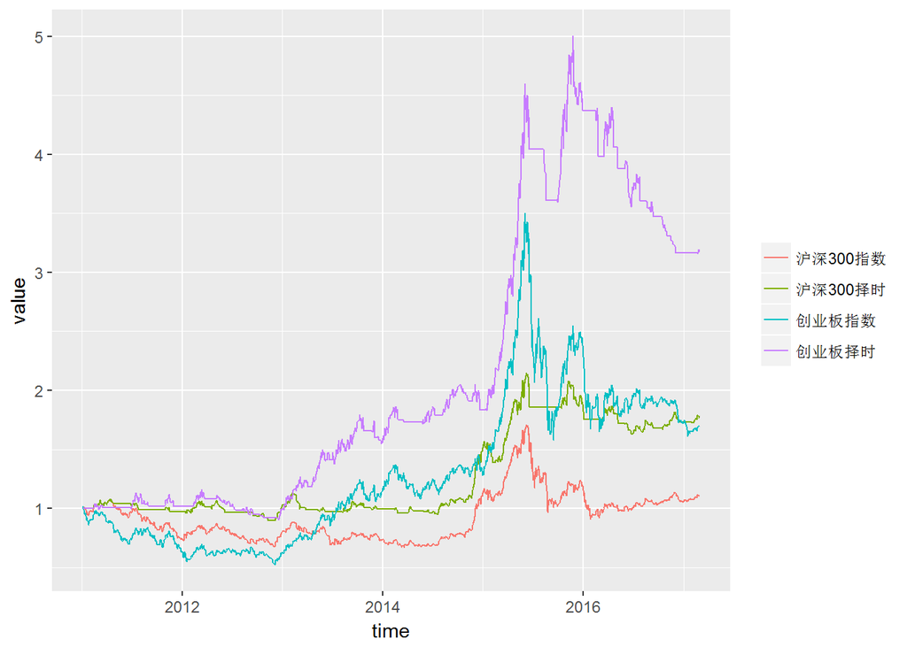

择时模型和指数的收益率统计如下表：

|  | 沪深300指 | 沪深300LLT | 创业板指 | 创业板MA |
| --- | --- | --- | --- | --- |
| 2011-01-04 ~ 2011-12-30 | -25.0% | -2.5% | -35.9% | 1.9% |
| 2012-01-04 ~ 2012-12-31 | 7.6% | 5.4% | -2.1% | -1.7% |
| 2013-01-04 ~ 2013-12-31 | -7.6% | -3.2% | 82.7% | 55.7% |
| 2014-01-02 ~ 2014-12-31 | 51.7% | 52.4% | 12.8% | 17.7% |
| 2015-01-05 ~ 2015-12-31 | 5.6% | 24.3% | 84.4% | 138.1% |
| 2016-01-04 ~ 2016-12-30 | -11.3% | -8.1% | -27.7% | -27.5% |
| 2017-01-03 ~ 2017-02-27 | 4.1% | 1.9% | -1.8% | 0.2% |
| 累计收益率 | 10.2% | 76.7% | 69.4% | 217.3% |
| 年化收益率 | 1.6% | 9.7% | 8.9% | 20.6% |
| 年化波动率 | 24.3% | 15.6% | 33.0% | 22.2% |
| 年化Sharpe值 | 6.5% | 62.3% | 27.1% | 92.8% |
| 最大回撤 | 46.7% | 24.0% | 54.9% | 36.8% |

择时模型最近10个交易日的信号如下表：

| 日期 | 沪深300收盘价 | 沪深300LLT | 沪深300择时信号 | 创业板收盘价 | 创业板MA30 | 创业板择时信号 |
| --- | --- | --- | --- | --- | --- | --- |
| 2017-02-14 | 3435.804 | 3384.812 | hold | 1909.395 | 1913.950 |  |
| 2017-02-15 | 3421.713 | 3388.191 | hold | 1892.357 | 1911.408 |  |
| 2017-02-16 | 3440.933 | 3391.563 | hold | 1897.630 | 1909.424 |  |
| 2017-02-17 | 3421.442 | 3394.752 | hold | 1882.869 | 1906.878 |  |
| 2017-02-20 | 3471.393 | 3398.764 | hold | 1894.962 | 1904.642 |  |
| 2017-02-21 | 3482.823 | 3404.565 | hold | 1921.077 | 1903.236 | buy |
| 2017-02-22 | 3489.757 | 3410.666 | hold | 1919.973 | 1900.849 | hold |
| 2017-02-23 | 3473.324 | 3416.147 | hold | 1925.951 | 1898.915 | hold |
| 2017-02-24 | 3473.852 | 3420.827 | hold | 1938.445 | 1898.029 | hold |
| 2017-02-27 | 3446.223 | 3424.381 | hold | 1926.772 | 1896.868 | hold |

### (d)网格交易

在经历了三轮股灾，A股逐步回归正常，在过去的一段时间呈现一个震荡的格局，如果未来没有增量信息，很可能维持震荡。结合股指期货的贴水，前期研究了一下网格交易。网格交易的结果如下图：

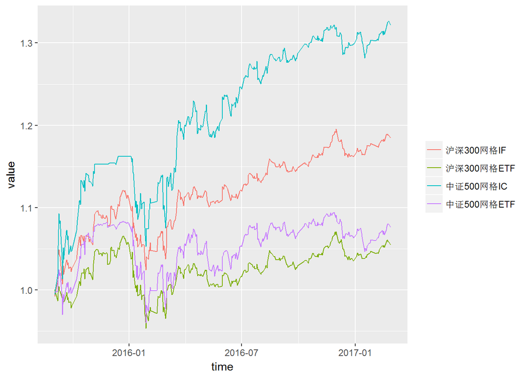

网格交易沪深300股指期货的最新仓位是34.7%，中证500股指期货的最新仓位是38.4%,网格交易的收益统计如下表：

|  | 沪深300指数 | 沪深300网格IF | 沪深300网格ETF | 中证500指数 | 中证500网格IC | 中证500网格ETF |
| --- | --- | --- | --- | --- | --- | --- |
| 2015-09-02 ~ 2015-12-31 | 11.0% | 11.1% | 5.6% | 23.5% | 16.2% | 8.1% |
| 2016-01-04 ~ 2016-12-30 | -11.3% | 4.7% | -1.8% | -17.8% | 11.8% | -1.6% |
| 2017-01-03 ~ 2017-02-27 | 4.1% | 1.8% | 1.7% | 2.6% | 1.7% | 1.1% |
| 累计收益率 | 2.5% | 18.5% | 5.5% | 4.1% | 32.2% | 7.6% |
| 年化收益率 | 1.7% | 12.0% | 3.6% | 2.7% | 20.5% | 5.0% |
| 年化波动率 | 22.4% | 9.4% | 9.2% | 30.2% | 13.8% | 11.8% |
| 年化Sharpe值 | 7.4% | 128.1% | 39.8% | 9.1% | 148.5% | 42.7% |
| 最大回撤 | 26.4% | 8.6% | 10.5% | 33.5% | 9.4% | 11.4% |

## E、选股

### (a)超级小盘股

作为多因子选股的第一部分，有必要从市值因子说起。 下面利用总市值因子，在中证全指的成分股内，选出市值最小的100只股票，这里剔除了ST、新上市、停牌和涨停的股票，100只股票等权配置，每月换仓一次，交易成本千分之三。超级小盘股策略的净值表现如下图。

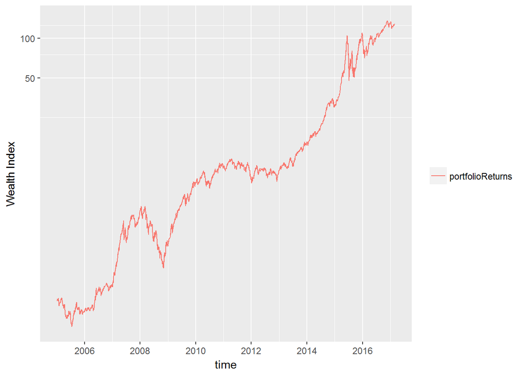

超级小盘股的收益统计如下表：

|  | 超级小盘股 | 沪深300 | 中证500 |
| --- | --- | --- | --- |
| 2005-01-05 ~ 2005-12-30 | -16.7% | -6.0% | -12.8% |
| 2006-01-04 ~ 2006-12-29 | 55.8% | 121.0% | 100.7% |
| 2007-01-04 ~ 2007-12-28 | 265.1% | 161.5% | 186.6% |
| 2008-01-02 ~ 2008-12-31 | -44.5% | -65.9% | -60.8% |
| 2009-01-05 ~ 2009-12-31 | 205.8% | 96.7% | 131.3% |
| 2010-01-04 ~ 2010-12-31 | 32.2% | -12.5% | 10.5% |
| 2011-01-04 ~ 2011-12-30 | -19.4% | -25.0% | -33.8% |
| 2012-01-04 ~ 2012-12-31 | 15.3% | 7.6% | 0.3% |
| 2013-01-04 ~ 2013-12-31 | 63.3% | -7.6% | 16.9% |
| 2014-01-02 ~ 2014-12-31 | 88.8% | 51.7% | 39.0% |
| 2015-01-05 ~ 2015-12-31 | 254.4% | 5.6% | 43.1% |
| 2016-01-04 ~ 2016-12-30 | 21.2% | -11.3% | -17.8% |
| 2017-01-03 ~ 2017-02-27 | -2.3% | 4.1% | 2.6% |
| 累计收益率 | 12680.1% | 250.7% | 553.2% |
| 年化收益率 | 49.1% | 10.9% | 16.7% |
| 年化波动率 | 35.9% | 28.5% | 32.5% |
| 年化Sharpe值 | 136.9% | 38.1% | 51.3% |
| 最大回撤 | 66.3% | 72.3% | 72.4% |

### (b)银行股轮动

银行股轮动是参考集思录的热门贴银行股评级而来的，数据的提取和参数的设置和原贴有一定的差别，所以轮动的效果也会不太一样，不过回测的效果还不错，从现在开始跟踪。2013年以来银行股轮动的结果如下图：

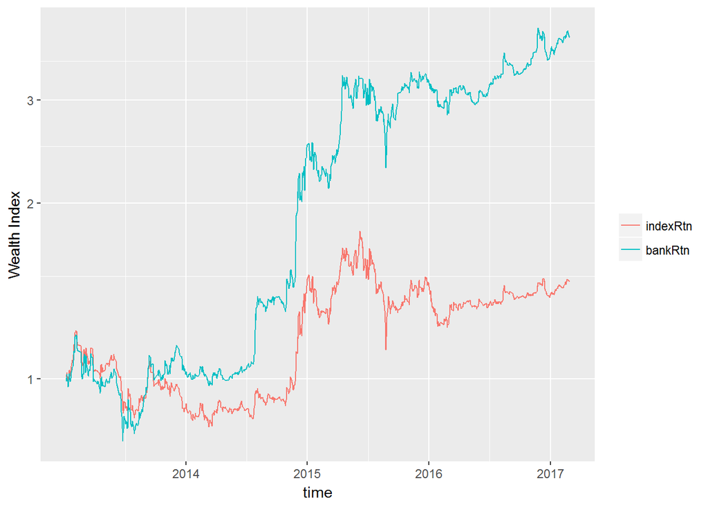

银行股轮动的收益统计如下表：

|  | 申万银行 | 银行股轮动 |
| --- | --- | --- |
| 2013-01-04 ~ 2013-12-31 | -9.2% | 3.0% |
| 2014-01-02 ~ 2014-12-31 | 63.2% | 144.5% |
| 2015-01-05 ~ 2015-12-31 | -1.4% | 29.0% |
| 2016-01-04 ~ 2016-12-30 | -4.9% | 10.5% |
| 2017-01-03 ~ 2017-02-27 | 5.6% | 7.0% |
| 累计收益率 | 46.7% | 284.1% |
| 年化收益率 | 9.7% | 38.3% |
| 年化波动率 | 28.5% | 32.4% |
| 年化Sharpe值 | 33.9% | 118.0% |
| 最大回撤 | 37.4% | 34.2% |

银行股轮动的最新得分如下表：

| 日期 | 代码 | 简称 | PB | 预期ROE | 翻倍期 | 持仓 |
| --- | --- | --- | --- | --- | --- | --- |
| 2017-02-27 | EQ600015 | 华夏银行 | 0.84 | 0.15 | 3.8 | hold |
| 2017-02-27 | EQ601818 | 光大银行 | 0.78 | 0.12 | 3.8 |  |
| 2017-02-27 | EQ601288 | 农业银行 | 0.81 | 0.12 | 4.1 |  |
| 2017-02-27 | EQ601328 | 交通银行 | 0.75 | 0.10 | 4.2 |  |
| 2017-02-27 | EQ601988 | 中国银行 | 0.78 | 0.11 | 4.2 |  |
| 2017-02-27 | EQ000001 | 平安银行 | 0.82 | 0.12 | 4.2 |  |
| 2017-02-27 | EQ601398 | 工商银行 | 0.86 | 0.13 | 4.5 |  |
| 2017-02-27 | EQ601166 | 兴业银行 | 0.93 | 0.14 | 4.6 |  |
| 2017-02-27 | EQ601939 | 建设银行 | 0.95 | 0.14 | 4.9 |  |
| 2017-02-27 | EQ600000 | 浦发银行 | 1.00 | 0.14 | 5.2 |  |
| 2017-02-27 | EQ600016 | 民生银行 | 1.01 | 0.13 | 5.9 |  |
| 2017-02-27 | EQ601169 | 北京银行 | 1.08 | 0.14 | 6.1 |  |
| 2017-02-27 | EQ601009 | 南京银行 | 1.19 | 0.15 | 6.3 |  |
| 2017-02-27 | EQ601998 | 中信银行 | 0.99 | 0.11 | 6.4 |  |
| 2017-02-27 | EQ600036 | 招商银行 | 1.23 | 0.15 | 6.5 |  |
| 2017-02-27 | EQ002142 | 宁波银行 | 1.44 | 0.16 | 7.1 |  |
| 2017-02-27 | EQ600919 | 江苏银行 | 1.44 | 0.13 | 8.7 |  |
| 2017-02-27 | EQ601997 | 贵阳银行 | 1.95 | 0.17 | 8.8 |  |
| 2017-02-27 | EQ601229 | 上海银行 | 1.39 | 0.12 | 9.0 |  |
| 2017-02-27 | EQ600926 | 杭州银行 | 1.64 | 0.10 | 12.1 |  |
| 2017-02-27 | EQ601128 | 常熟银行 | 2.68 | 0.10 | 17.2 |  |
| 2017-02-27 | EQ600908 | 无锡银行 | 2.66 | 0.10 | 17.6 |  |
| 2017-02-27 | EQ603323 | 吴江银行 | 2.61 | 0.08 | 21.3 |  |
| 2017-02-27 | EQ002807 | 江阴银行 | 4.01 | 0.09 | 23.7 |  |